# User Type and Duration of Ford GoBike Usage

## by Murtala Umar Adamu

## Investigation Overview

This presentation is aimed at outlining how user type impact the duration of usage of Ford Gobikes. The main focus will be on the user type (i.e Customers or Subscribers) and duration_sec, which will be converted to minutes for convenience of usage.

## Data Overview

The Ford Gobike System Dataset is a bike sharing dataset that captures the rides by users of the system. The dataset has 174952 rows and 20 columns after cleaning and feature engineering. Additionally, the dataset covers the greater San Francisco Bay Area.

## Count of User Type

There are two user types of Ford Gobike, customers who use the bikes but are not subscribed and subscribers who are registered as users. Plotted on a bar chart, we see that there are more subscribers than customers who use the gobike system.

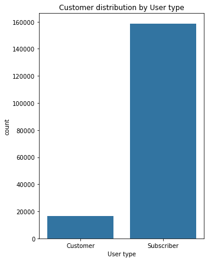

## Distribution of User Type to Duration

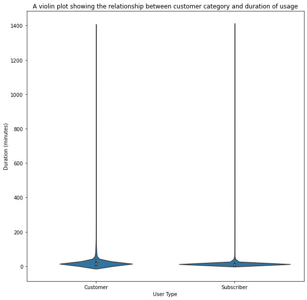

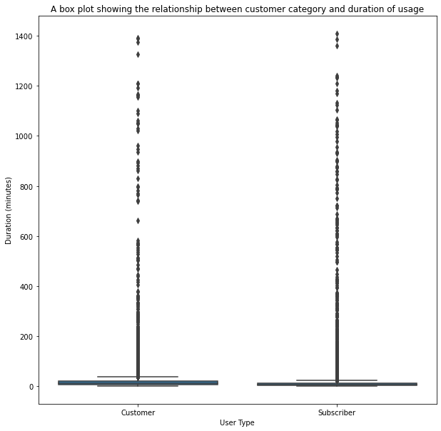

## Distribution of User Type by Duration & Age

In the scatter plot that follows, we can see the user type distribution plotted against duration (in minutes) and age. This gives us an insight into age of the users and the duration which they use the bikes for. We see which user type use the bike for longer periods. Interestingly, we can see that the majorilty of those who used the bikes longer are the subscribers to the sytem.

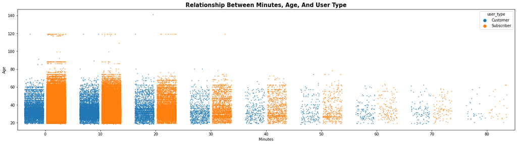